# Suspicious XLOCs

Libraries and fucntions

```r
source("f.R")
library(pheatmap)
```

Define species and tissue

```r
sp <- "Mouse"
t <- "Liver"
```

Load data (raw and normalised counts)

```r
rawData <- rawCounts(sp)
normData <- logTransform(loadData(sp))

normData
```

```
## class: SummarizedExperiment
## dim: 62931 316
## metadata(0):
## assays(2): normcounts logcounts
## rownames(62931): ENSMUSG00000000001 ENSMUSG00000000003 ...
##   XLOC_046120 XLOC_046121
## rowData names(0):
## colnames(316): Brain.e10.5.1 Brain.e10.5.2 ... Liver.P63.3
##   Liver.P63.4
## colData names(5): files group sex tissue timePoint
```

Let’s select several early liver samples and plot them against average expression (X-Axis) Note the group of genes that have almost zero average expression, but are expressed in **Liver.e10.5.4** and **Liver.e12.5.3**.

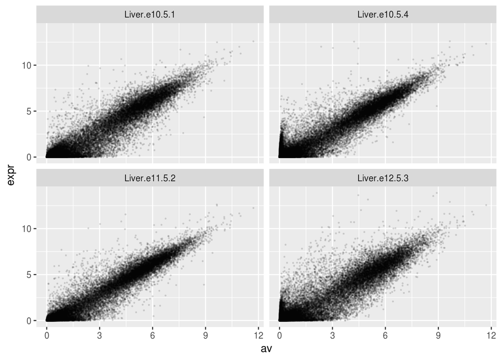

```r
samples <- c("Liver.e10.5.1", "Liver.e10.5.4", "Liver.e11.5.2", "Liver.e12.5.3")

as.data.frame(assay(normData, "logcounts")[, samples]) %>%
  rownames_to_column(var = "geneId") %>%
  mutate(av = rowMeans(assay(normData, "logcounts"))) %>%
  gather(id, expr, -one_of(c("geneId", "av"))) %>%
  ggplot() + geom_point(aes(x = av, y = expr), size = 0.3, alpha = 0.1) + facet_wrap(~id)
```

MA plots for the same genes. X-Axis is logorithmise for better resolution. Genes are coloured depending on whether it’s a protein-coding gene or an XLOC.

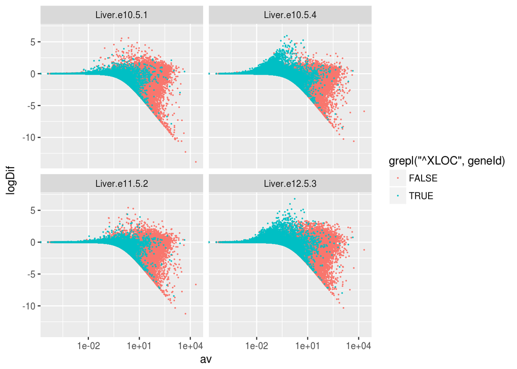

```r
as.data.frame(assay(normData, "logcounts")[, samples]) %>%
  rownames_to_column(var = "geneId") %>%
  mutate(av = rowMeans(assay(normData, "normcounts"))) %>%
  gather(id, expr, -one_of(c("geneId", "av"))) %>%
  mutate(logDif = expr - log2(av + 1)) %>%
  ggplot() + geom_point(aes(x = av, y = logDif, col = grepl("^XLOC", geneId)), size = 0.1) +
  scale_x_log10() + facet_wrap(~id)
```

The group of strangely behaving genes is best noticeable for the **Liver.e10.5.4** sample. The huge skew is due to the fact that we are looking at the very early developmental stages, where most of the genes are not yet expressed. Let’s look at MA plot comparing **Liver.e10.5.4** and **Liver.e10.5.1** and using non-normalized counts.

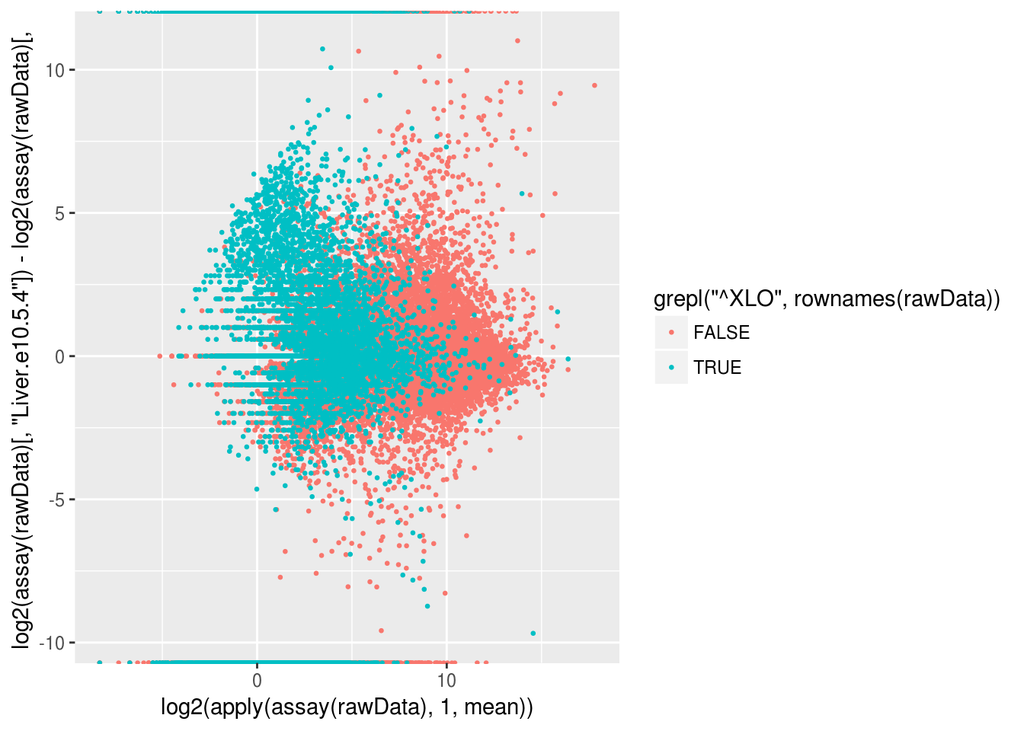

```r
ggplot() +
  geom_point(aes(x = log2(apply(assay(rawData), 1, mean)),
                 y = log2(assay(rawData)[, "Liver.e10.5.4"]) - log2(assay(rawData)[, "Liver.e10.5.1"]),
                 col = grepl("^XLO", rownames(rawData))), size = 0.5)
```

And that’s how this plot should look like.

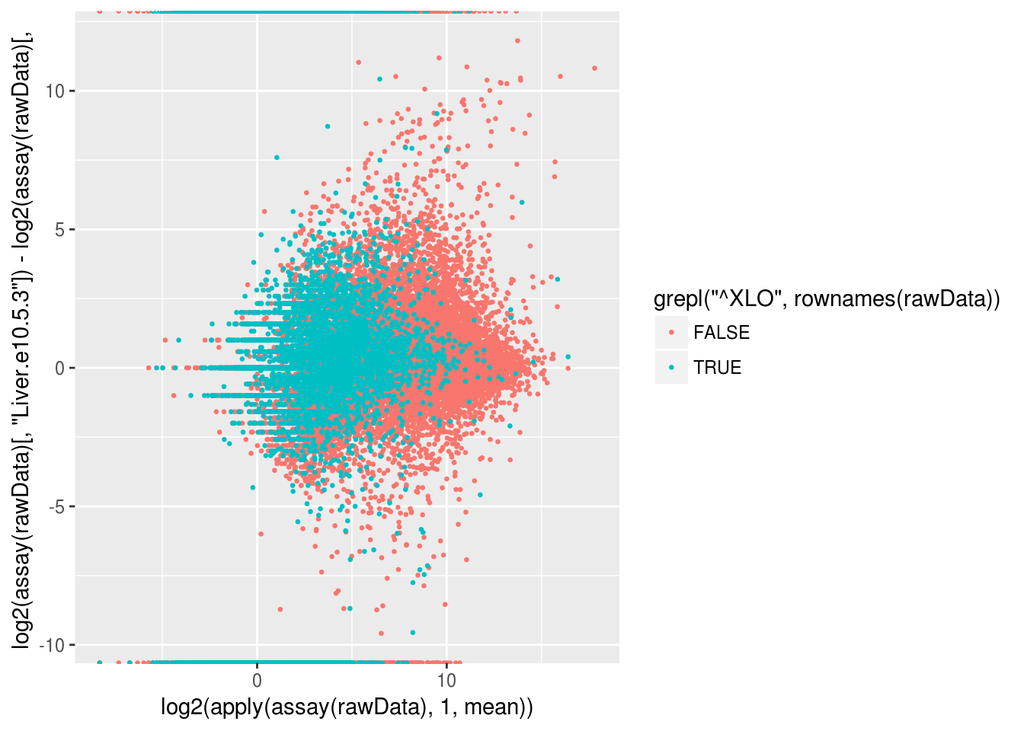

```r
ggplot() +
  geom_point(aes(x = log2(apply(assay(rawData), 1, mean)),
                 y = log2(assay(rawData)[, "Liver.e10.5.3"]) - log2(assay(rawData)[, "Liver.e10.5.1"]),
                 col = grepl("^XLO", rownames(rawData))), size = 0.5)
```

Now let’s select the suspicious genes (very roughly). We also leave only the genes that are expressed in **Liver.e10.5.4**

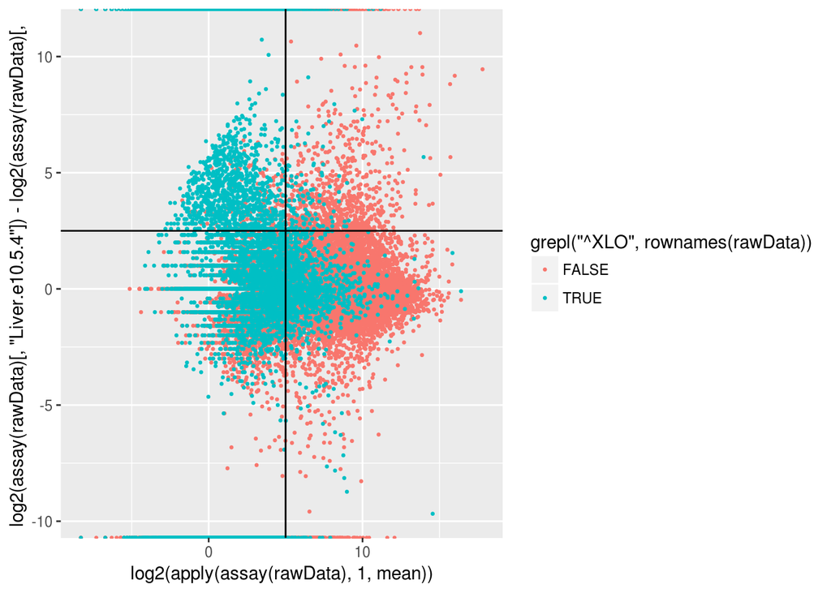

```r
ggplot() +
  geom_point(aes(x = log2(apply(assay(rawData), 1, mean)),
                 y = log2(assay(rawData)[, "Liver.e10.5.4"]) - log2(assay(rawData)[, "Liver.e10.5.1"]),
                 col = grepl("^XLO", rownames(rawData))), size = 0.5) +
  geom_vline(xintercept = 5) + geom_hline(yintercept = 2.5)
```

```r
selGenes <- log2(apply(assay(rawData), 1, mean)) < 5 &
  (log2(assay(rawData)[, "Liver.e10.5.4"]) - log2(assay(rawData)[, "Liver.e10.5.1"]) > 2.5) &
  assay(rawData)[, "Liver.e10.5.4"] > 15
selGenes[is.na(selGenes)] <- F
```

We have selected 1525. Among them 1368 XLOCs and 157 protein coding genes.

Let’s make a heatmap for all Liver samples to refine our selection.

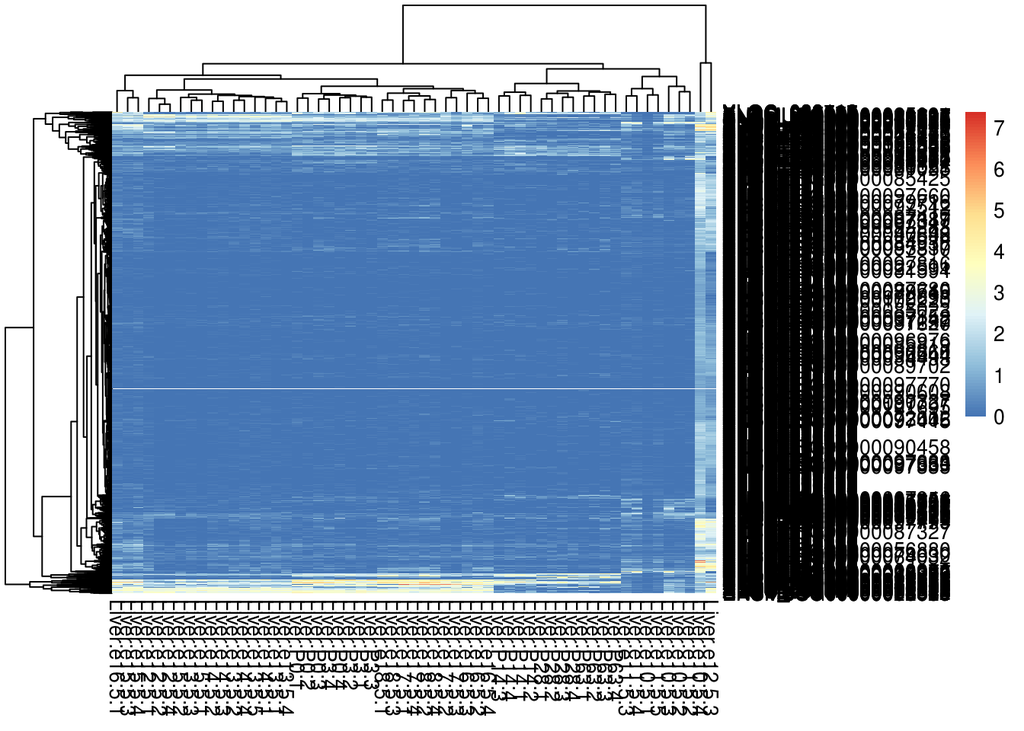

```r
ph <- pheatmap(assay(normData, "logcounts")[selGenes, normData$tissue == "Liver"])
```

So, it’s easy to spot the two samples, where something went wrong. We also see that bunch of the selected genes is stil expressed in further timepoints and we are interested mostly in the huge cluster in the middle.

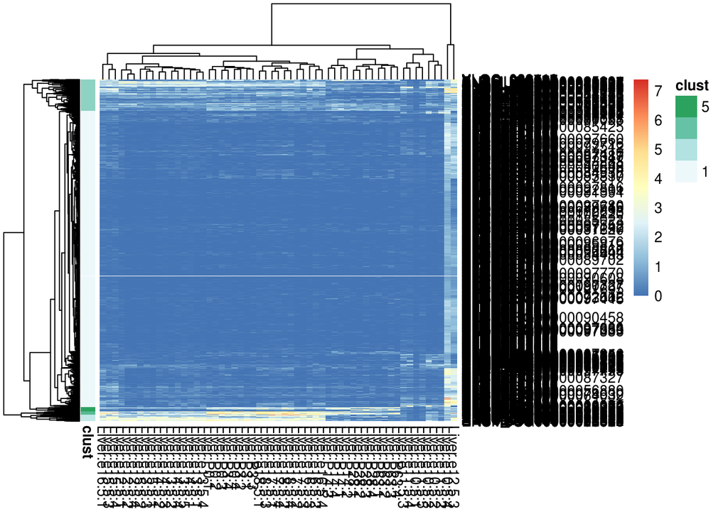

```r
clust <- cutree(ph$tree_row, 5)
pheatmap(assay(normData, "logcounts")[selGenes, normData$tissue == "Liver"],
         annotation_row = data.frame(row.names = names(clust), clust = clust))
```

Now we can take only the genes from this huge cluster.

```r
selGenes[names(clust)[clust != 1]] <- F
```

Now we have 1322: 1227 XLOCs and 95 protein coding genes.

Check where are they expressed.

**Brain**

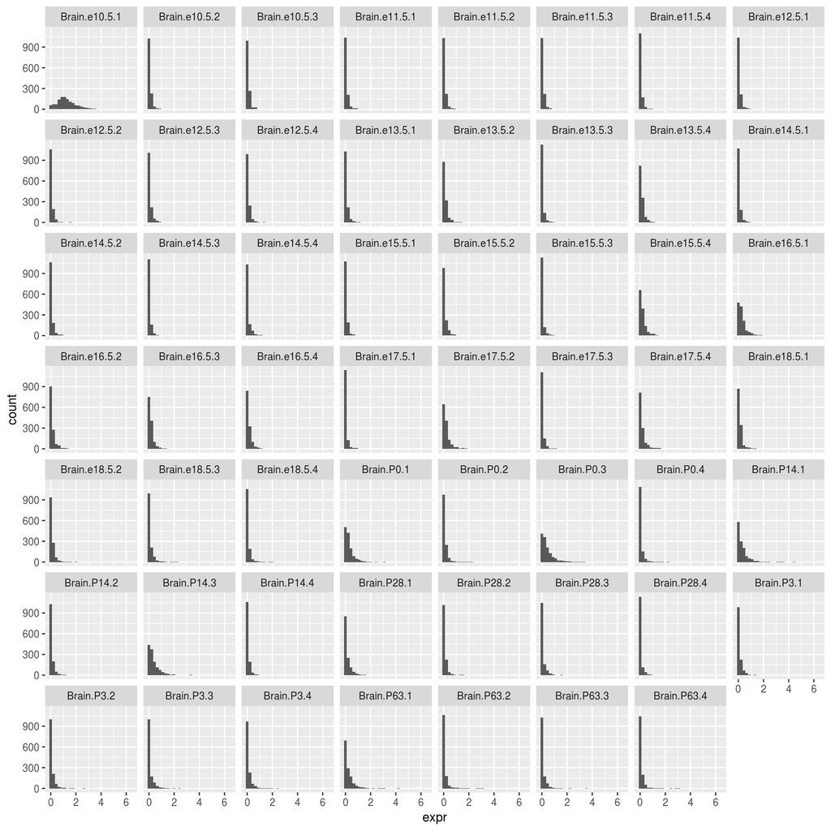

```r
assay(normData, "logcounts") %>%
  as.data.frame %>%
  rownames_to_column(var = "geneId") %>%
  as.tibble %>%
  filter(selGenes) %>%
  gather(id, expr, -(geneId)) %>%
  left_join(colData(normData) %>%
              as.data.frame() %>%
              rownames_to_column(var = "id"), by = "id") %>%
  filter(tissue == "Brain") %>%
  ggplot() + geom_histogram(aes(x = expr)) + facet_wrap(~id)
```

**Cerebellum**

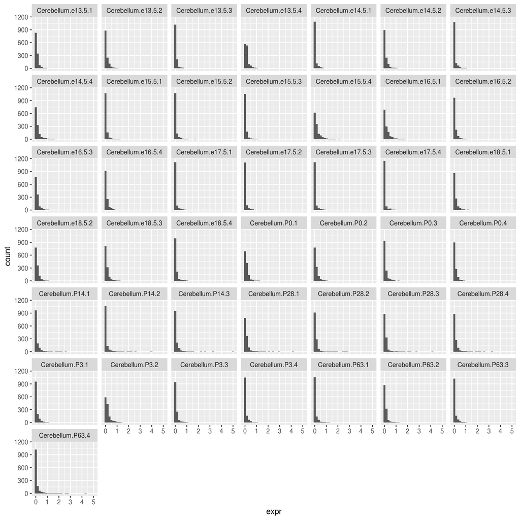

```r
assay(normData, "logcounts") %>%
  as.data.frame %>%
  rownames_to_column(var = "geneId") %>%
  as.tibble %>%
  filter(selGenes) %>%
  gather(id, expr, -(geneId)) %>%
  left_join(colData(normData) %>%
              as.data.frame() %>%
              rownames_to_column(var = "id"), by = "id") %>%
  filter(tissue == "Cerebellum") %>%
  ggplot() + geom_histogram(aes(x = expr)) + facet_wrap(~id)
```

**Heart**

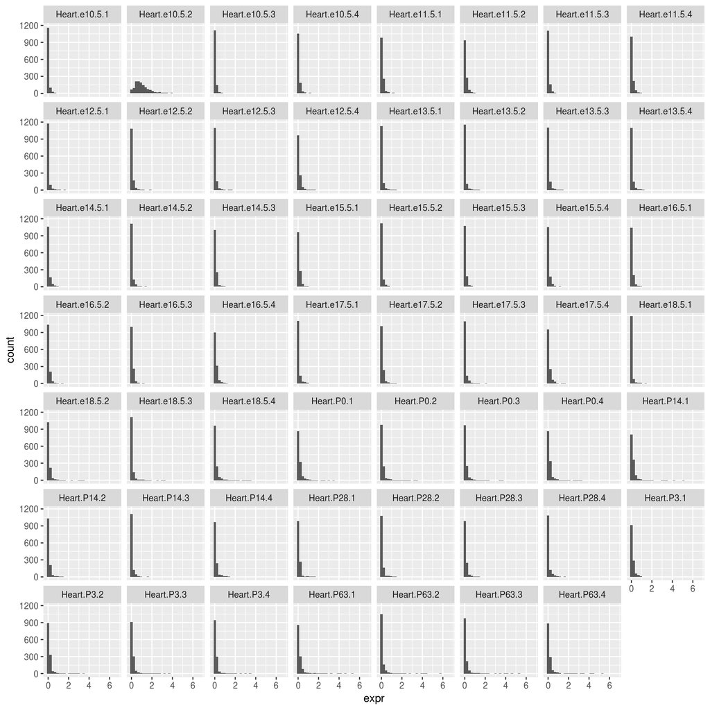

```r
assay(normData, "logcounts") %>%
  as.data.frame %>%
  rownames_to_column(var = "geneId") %>%
  as.tibble %>%
  filter(selGenes) %>%
  gather(id, expr, -(geneId)) %>%
  left_join(colData(normData) %>%
              as.data.frame() %>%
              rownames_to_column(var = "id"), by = "id") %>%
  filter(tissue == "Heart") %>%
  ggplot() + geom_histogram(aes(x = expr)) + facet_wrap(~id)
```

**Liver**

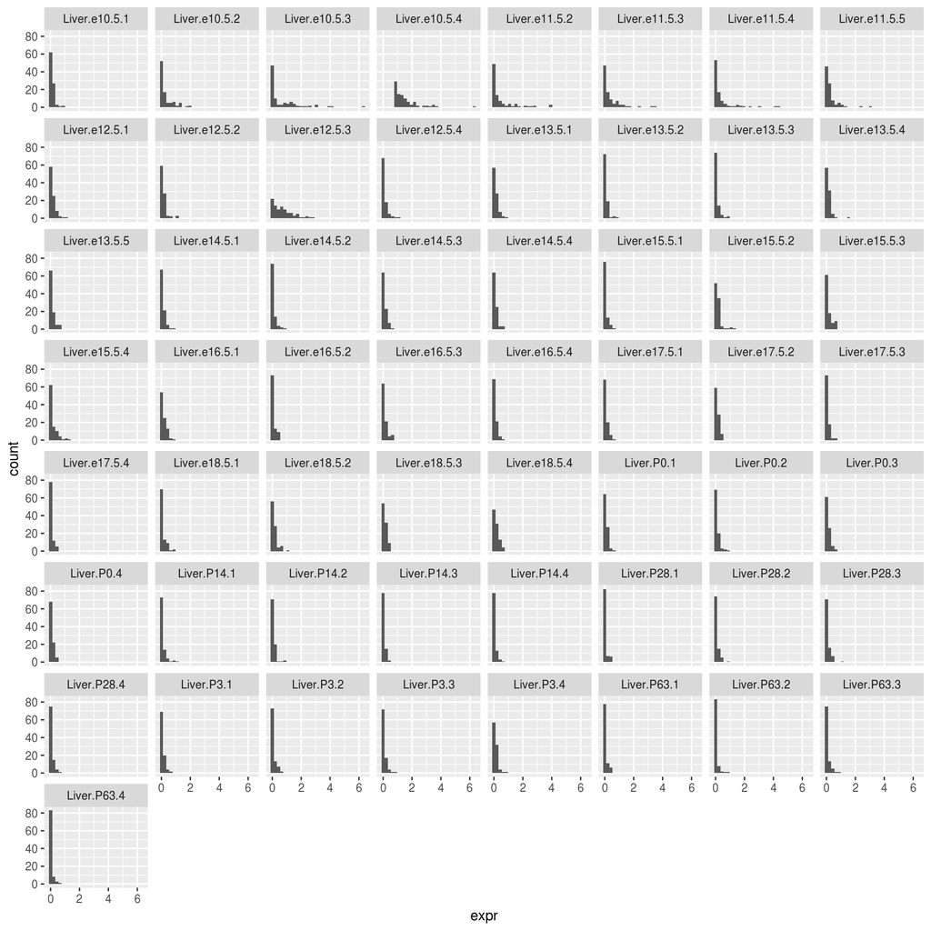

```r
assay(normData, "logcounts") %>%
  as.data.frame %>%
  rownames_to_column(var = "geneId") %>%
  as.tibble %>%
  filter(selGenes & grepl("^ENS", geneId)) %>%
  gather(id, expr, -(geneId)) %>%
  left_join(colData(normData) %>%
              as.data.frame() %>%
              rownames_to_column(var = "id"), by = "id") %>%
  filter(tissue == "Liver") %>%
  ggplot() + geom_histogram(aes(x = expr)) + facet_wrap(~id)
```

**Kidney**

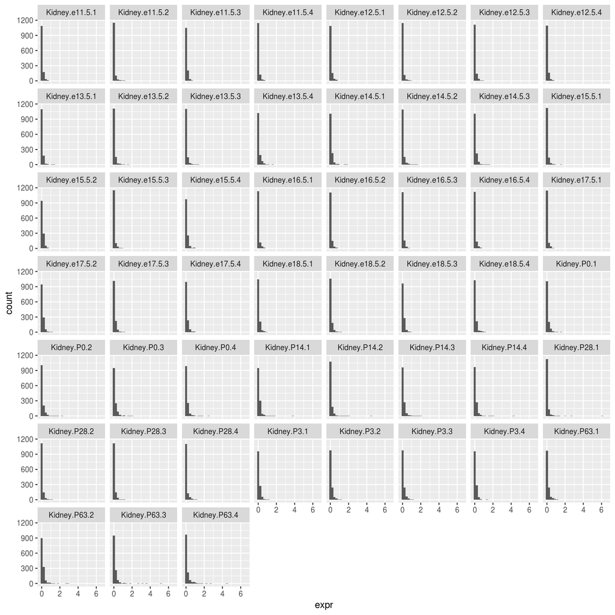

```r
assay(normData, "logcounts") %>%
  as.data.frame %>%
  rownames_to_column(var = "geneId") %>%
  as.tibble %>%
  filter(selGenes) %>%
  gather(id, expr, -(geneId)) %>%
  left_join(colData(normData) %>%
              as.data.frame() %>%
              rownames_to_column(var = "id"), by = "id") %>%
  filter(tissue == "Kidney") %>%
  ggplot() + geom_histogram(aes(x = expr)) + facet_wrap(~id)
```